# R Notebook

# Unsupervised learning

## Dimension reduction with PCA

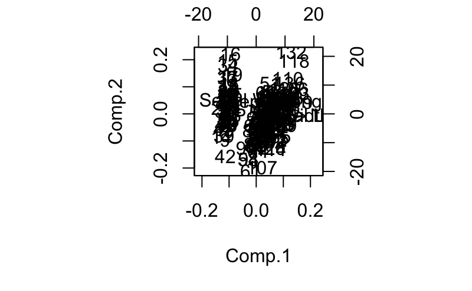

```r
data(iris)
X = iris[,-5]
cls = as.numeric(iris$Species)

# The usual manner to do PCA in R
pca = princomp(X)
biplot(pca)
```

We can compare the observations in the orignal space with their projection on the new variables:

```r
Y = predict(pca)[,1:2] # Projection of the original data on the two first PC axes

# #The `predict` action is equivalent to these actions:
# U = pca$loadings[,1:2]
# dim(U) # 4 x 2
# Y = as.matrix(X) %*% U
# dim(Y)

# coordinates of the 1st individual in the original space (X)
X[1,]
```

|  | Sepal.Length | Sepal.Width | Petal.Length | Petal.Width |
| --- | --- | --- | --- | --- |
| 1 | 5.1 | 3.5 | 1.4 | 0.2 |

```r
# coordinates of the 1st individual in the projection space (Y = X * U)
Y[1,]
```

```
    Comp.1     Comp.2
-2.6841256  0.3193972
```

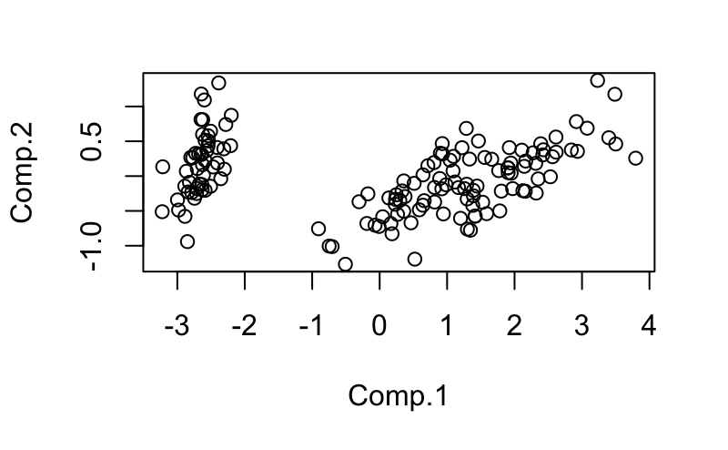

```r
plot(Y,col=cls)
```

## Another example of PCA with the decathlon data

Let’s first load the data (from internet):

```r
decathlon = read.table("http://math.agrocampus-ouest.fr/infoglueDeliverLive/digitalAssets/108286_decathlon.csv",header=TRUE,sep=';')

dim(decathlon)
```

```
[1] 41 14
```

Let’s just now focus on the athlet performance data:

```r
X = decathlon[,2:11] # We only keep the data related to the 10 competitions
rownames(X) = decathlon$X
```

> Exercise: perform a PCA and visualise the data in a 2-dimensional space. Then, indentify the most performant athelets.

```r
pca = princomp(X)

par(mfrow=c(1,2))
biplot(pca,col=c(0,2))
#biplot(pca,col=c(1,0))

Y = predict(pca)[,1:2]
plot(Y,type='n')
```

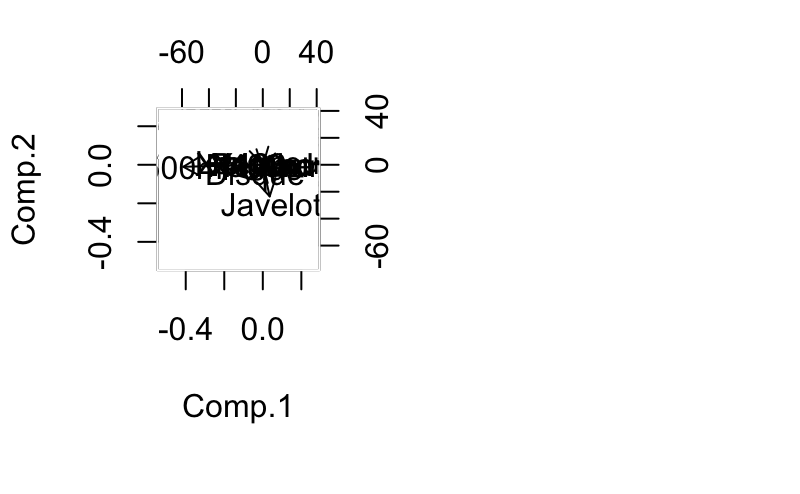

```r
text(Y,labels = rownames(X))
```

## Selection of the numbers of axes to retain

One of the rules is to retain the nb of axes such that the percentage of explained variance is larger to 90%:

```r
summary(pca)
```

```
Importance of components:
                           Comp.1    Comp.2    Comp.3      Comp.4      Comp.5       Comp.6
Standard deviation     11.6106540 4.7891085 3.1220607 1.056984087 0.589720672 0.3642552340
Proportion of Variance  0.7965959 0.1355296 0.0575980 0.006601788 0.002055026 0.0007840365
Cumulative Proportion   0.7965959 0.9321255 0.9897235 0.996325247 0.998380274 0.9991643100
                            Comp.7      Comp.8       Comp.9      Comp.10
Standard deviation     0.249171229 0.222227318 0.1582500495 7.006272e-02
Proportion of Variance 0.000366877 0.000291823 0.0001479832 2.900673e-05
Cumulative Proportion  0.999531187 0.999823010 0.9999709933 1.000000e+00
```

Here, two PCA components are enough to explain 93% of the variance.

The other rule it to look for a break in the eigenvalue scree:

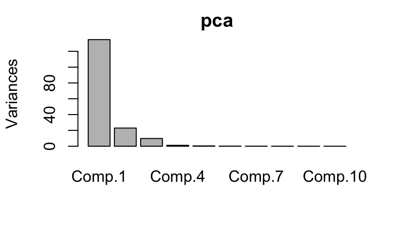

```r
screeplot(pca)
```

On this example, we perhaps would prefer $d=3$.

## PCA on scaled data

```r
pca = princomp(X,cor = TRUE)

par(mfrow=c(1,2))
biplot(pca,col=c(0,2))
#biplot(pca,col=c(1,0))

Y = predict(pca)[,1:2]
plot(Y,type='n')
```

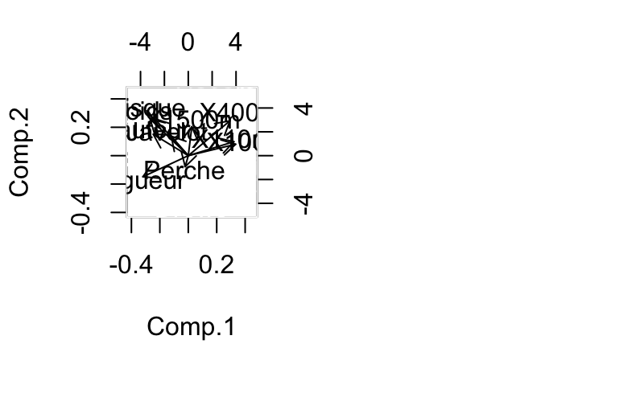

```r
text(Y,labels = rownames(X))
```

# Clustering

## Hierarchical clustering

In order to highlight the main features of kmeans and HC, let’s consider the `swiss` data:

```r
data(swiss)
?swiss
```

Let’s first try to apply HC on these data. A general call to HC in R can be done as follows:

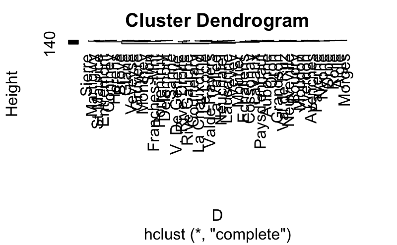

```r
library(class)
? hclust

D = dist(swiss)
hc = hclust(D,method = "complete")
plot(hc)
```

> Remark: we observe here that `hclust` can be applied to any type of data if we are able to compute a distance for these data. Conversly, kmeans is mostly restricted to continuous data due to the need to compute centers.

> Exercise: apply the different methods (group distances) of HC to compare the results.

```r
D = dist(swiss)
par(mfrow=c(2,2))
hc1 = hclust(D,method = "complete"); plot(hc1)
hc2 = hclust(D,method = "single"); plot(hc2)
```

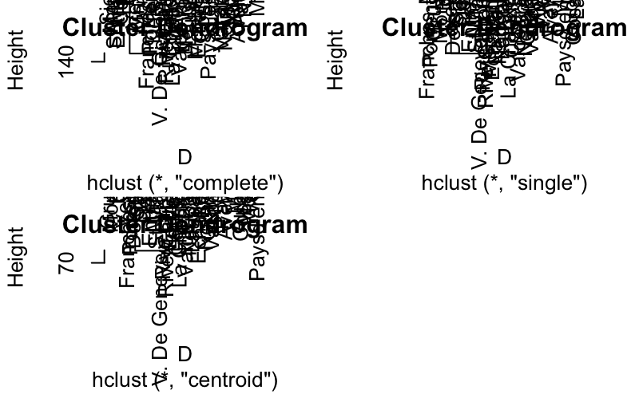

```r
hc3 = hclust(D,method = "centroid"); plot(hc3)
hc4 = hclust(D,method = "ward.D2"); plot(hc4)
```

> Remark: we can see here that the different methods lead to quite different dendrogram, leading in turn to different choices of numbers of clusters.

Let’s remember that the clustering aims to help the analyst to understand the data. The choice of a method should be done according to this idea!

A good way to verify that the different clustering make sense or not is to visualise the data with the clustering as an additional information (thanks to the colors).

```r
hc4 = hclust(D,method = "ward.D2")
cl4 = cutree(hc4,k = 2)
cl4
```

```
  Courtelary     Delemont Franches-Mnt      Moutier   Neuveville   Porrentruy        Broye
           1            2            2            1            1            2            2
       Glane      Gruyere       Sarine      Veveyse        Aigle      Aubonne     Avenches
           2            2            2            2            1            1            1
    Cossonay    Echallens     Grandson     Lausanne    La Vallee       Lavaux       Morges
           1            1            1            1            1            1            1
      Moudon        Nyone         Orbe         Oron      Payerne Paysd'enhaut        Rolle
           1            1            1            1            1            1            1
       Vevey      Yverdon      Conthey    Entremont       Herens     Martigwy      Monthey
           1            1            2            2            2            2            2
  St Maurice       Sierre         Sion       Boudry La Chauxdfnd     Le Locle    Neuchatel
           2            2            2            1            1            1            1
  Val de Ruz ValdeTravers V. De Geneve  Rive Droite  Rive Gauche
           1            1            1            1            1
```

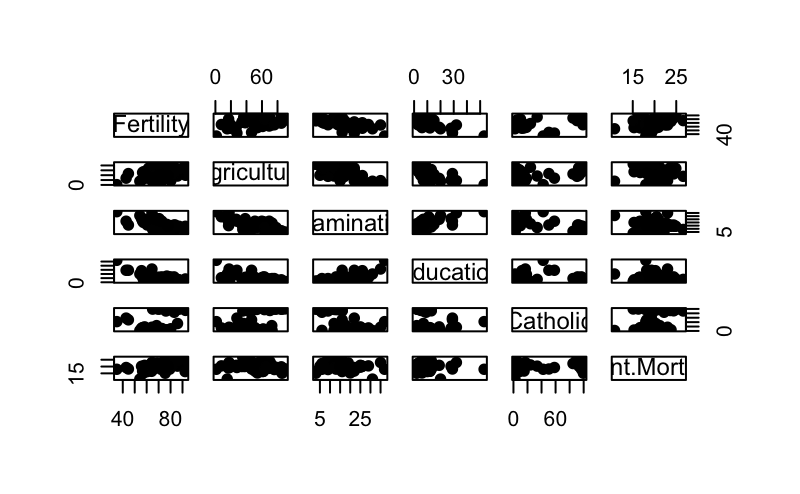

```r
plot(swiss,col=cl4,pch=19)
```

```r
cl1 = cutree(hc1,k = 3)
cl2 = cutree(hc2,k = 4)
cl3 = cutree(hc3,k = 3)
par(mfrow = c(2,2))
plot(swiss[,c(3,5)],col=cl1,pch=19,main='Complete')
plot(swiss[,c(3,5)],col=cl2,pch=19,main='Single')
```

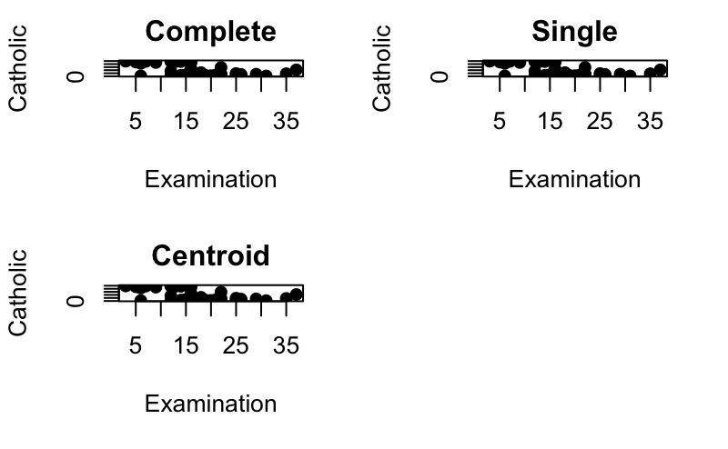

```r
plot(swiss[,c(3,5)],col=cl3,pch=19,main='Centroid')
plot(swiss[,c(3,5)],col=cl4,pch=19,main='Ward')
```

## Kmeans

Let’s now have a look at the same data with kmeans.

```r
?kmeans
```

A basic call to kmeans would be:

```r
data(swiss)
out = kmeans(swiss,centers = 2)
out
```

```
K-means clustering with 2 clusters of sizes 16, 31

Cluster means:
  Fertility Agriculture Examination Education Catholic Infant.Mortality
1  80.55000    65.51875     9.43750   6.62500 96.15000          20.7750
2  64.77097    42.99032    20.12903  13.22581 12.75355          19.5129

Clustering vector:
  Courtelary     Delemont Franches-Mnt      Moutier   Neuveville   Porrentruy        Broye
           2            1            1            2            2            1            1
       Glane      Gruyere       Sarine      Veveyse        Aigle      Aubonne     Avenches
           1            1            1            1            2            2            2
    Cossonay    Echallens     Grandson     Lausanne    La Vallee       Lavaux       Morges
           2            2            2            2            2            2            2
      Moudon        Nyone         Orbe         Oron      Payerne Paysd'enhaut        Rolle
           2            2            2            2            2            2            2
       Vevey      Yverdon      Conthey    Entremont       Herens     Martigwy      Monthey
           2            2            1            1            1            1            1
  St Maurice       Sierre         Sion       Boudry La Chauxdfnd     Le Locle    Neuchatel
           1            1            1            2            2            2            2
  Val de Ruz ValdeTravers V. De Geneve  Rive Droite  Rive Gauche
           2            2            2            2            2

Within cluster sum of squares by cluster:
[1]  6532.906 28886.723
 (between_SS / total_SS =  70.1 %)

Available components:

[1] "cluster"      "centers"      "totss"        "withinss"     "tot.withinss" "betweenss"
[7] "size"         "iter"         "ifault"
```

> Exercise: write a short script that plot the curve of J(k) for the data set at hand.

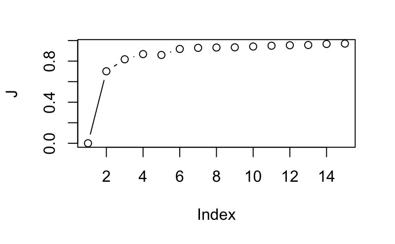

```r
J = rep(NA,15)
for (k in 1:15){
  out = kmeans(swiss,centers = k)
  J[k] = out$betweenss / out$totss
}

plot(J,type='b')
```

We observe on this small run that the curve can change with different initializations and we can even observe some non increasing curves for unlucky initializations. A way to avoid this initialization effect, we can average on several runs for each value of k:

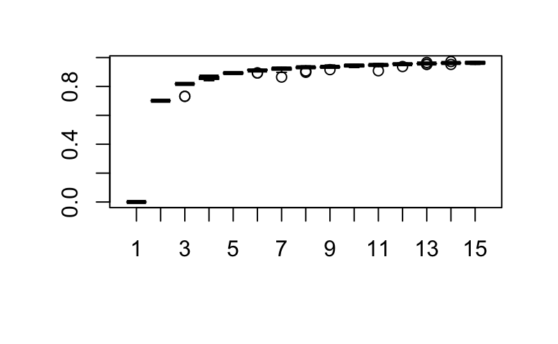

```r
J = matrix(NA,10,15)
for (k in 1:15){
  for (l in 1:10){
    out = kmeans(swiss,centers = k)
    J[l,k] = out$betweenss / out$totss
  }
}

boxplot(J,type='b')
```

On this example, I’d probably pick $k^*=5$ as the most appropriate number of clusters.

> Exercise: visualise the clustering result with a pair plot, and compare to the ones obtained with hclust.

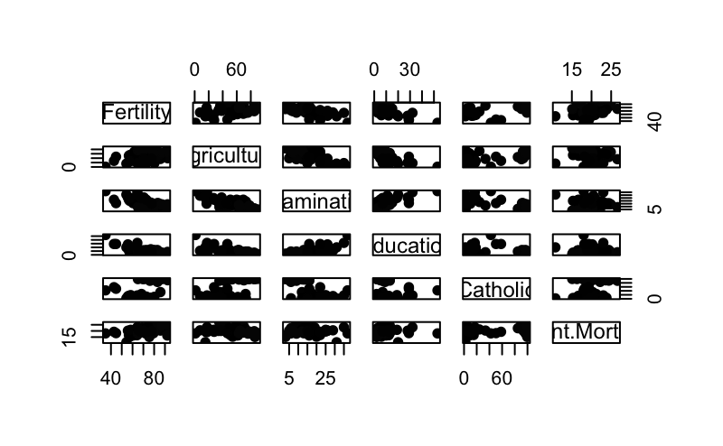

```r
out5 = kmeans(swiss, centers = 5, nstart = 10)
plot(swiss,col=out5$cluster,pch=19)
```

It looks like the two most discriminative variables are here ‘Agriculture’ and ‘Catholic’:

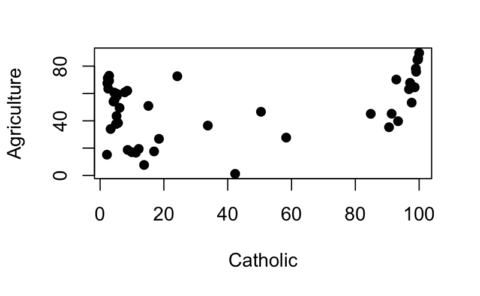

```r
plot(swiss[,c(5,2)],col=out5$cluster,pch=19)
```

Here, we clearly see that kmeans has a tendecy to create additional groups to model elongated clusters. So, here, perhaps, the kmeans solution with 3 groups would be better.

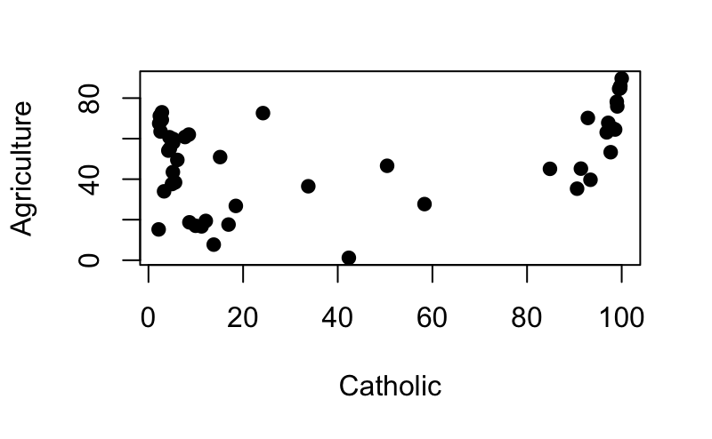

```r
out3 = kmeans(swiss, centers = 3, nstart = 10)
plot(swiss[,c(5,2)],col=out3$cluster,pch=19)
```

## The GMM and the EM algorithm

The EM algorithm is implemented for R in the `mclust` package:

```r
#install.packages("mclust")
library(mclust)
```

The help of the package is available as usual:

```r
?Mclust
```

A basic call to Mclust is as follows:

```r
data(swiss)
out = Mclust(swiss, G = 3)
```

```
fitting ...
```

> Exercise: have a look at what is inside `out` and to relate it with the GMM.

```r
out
```

```
'Mclust' model object: (EEE,3)

Available components:
 [1] "call"           "data"           "modelName"      "n"              "d"
 [6] "G"              "BIC"            "loglik"         "df"             "bic"
[11] "icl"            "hypvol"         "parameters"     "z"              "classification"
[16] "uncertainty"
```

```r
out$parameters
```

```
$pro
[1] 0.59574468 0.34042553 0.06382979

$mean
                      [,1]     [,2]     [,3]
Fertility        67.335714 80.55000 40.83333
Agriculture      44.900000 65.51875 25.16667
Examination      19.607143  9.43750 25.00000
Education        10.678571  6.62500 37.00000
Catholic          8.723571 96.15000 50.36667
Infant.Mortality 19.621429 20.77500 18.50000

$variance
$variance$modelName
[1] "EEE"

$variance$d
[1] 6

$variance$G
[1] 3

$variance$sigma
, , 1

                  Fertility Agriculture Examination    Education    Catholic Infant.Mortality
Fertility         56.324063  -11.930674 -16.8778115 -14.42933131  4.58112258        8.6486930
Agriculture      -11.930674  368.415980 -61.5283245 -73.35079786 -2.65834751      -11.6002660
Examination      -16.877812  -61.528324  34.9492781  28.40615501  0.75083587        0.7853343
Education        -14.429331  -73.350798  28.4061550  40.76291793  0.02387538        0.8498480
Catholic           4.581123   -2.658348   0.7508359   0.02387538 40.66932150       -0.0764924
Infant.Mortality   8.648693  -11.600266   0.7853343   0.84984802 -0.07649240        7.8731307

, , 2

                  Fertility Agriculture Examination    Education    Catholic Infant.Mortality
Fertility         56.324063  -11.930674 -16.8778115 -14.42933131  4.58112258        8.6486930
Agriculture      -11.930674  368.415980 -61.5283245 -73.35079786 -2.65834751      -11.6002660
Examination      -16.877812  -61.528324  34.9492781  28.40615501  0.75083587        0.7853343
Education        -14.429331  -73.350798  28.4061550  40.76291793  0.02387538        0.8498480
```

[output cut: 20 more lines]

```
Catholic           4.581123   -2.658348   0.7508359   0.02387538 40.66932150       -0.0764924
Infant.Mortality   8.648693  -11.600266   0.7853343   0.84984802 -0.07649240        7.8731307

$variance$cholSigma
                 Fertility Agriculture Examination Education    Catholic Infant.Mortality
Fertility         7.504936    -1.58971   -2.248895 -1.922646  0.61041462       1.15240065
Agriculture       0.000000    19.12822   -3.403527 -3.994478 -0.08824476      -0.51067390
Examination       0.000000     0.00000   -4.278756 -2.450949 -0.42611701      -0.38302481
Education         0.000000     0.00000    0.000000 -3.886303  0.05130754      -0.02234927
Catholic          0.000000     0.00000    0.000000  0.000000 -6.33282877       0.15586488
Infant.Mortality  0.000000     0.00000    0.000000  0.000000  0.00000000      -2.47241061


$Vinv
NULL
```

```r
out$loglik
```

```
[1] -934.9916
```

```r
out$classification
```

```
  Courtelary     Delemont Franches-Mnt      Moutier   Neuveville   Porrentruy        Broye
           1            2            2            1            1            2            2
       Glane      Gruyere       Sarine      Veveyse        Aigle      Aubonne     Avenches
           2            2            2            2            1            1            1
    Cossonay    Echallens     Grandson     Lausanne    La Vallee       Lavaux       Morges
           1            1            1            1            1            1            1
      Moudon        Nyone         Orbe         Oron      Payerne Paysd'enhaut        Rolle
           1            1            1            1            1            1            1
       Vevey      Yverdon      Conthey    Entremont       Herens     Martigwy      Monthey
           1            1            2            2            2            2            2
  St Maurice       Sierre         Sion       Boudry La Chauxdfnd     Le Locle    Neuchatel
           2            2            2            1            1            1            1
  Val de Ruz ValdeTravers V. De Geneve  Rive Droite  Rive Gauche
           1            1            3            3            3
```

> Exercise: Compare the GMM clustering with the ones obtained with kmeans and hclust.

```r
# Simple visualization of GMM result
data(swiss)
out = Mclust(swiss, G = 3)
```

```
fitting ...
```

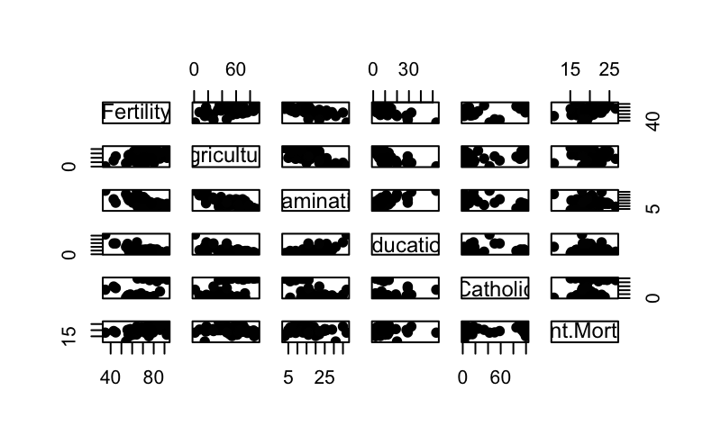

```r
plot(swiss, col=out$classification, pch=19)

# Comparison with kmeans and hclust on two specific variables (Examination / Catholic for instance)
par(mfrow = c(1,3))
```

```r
D = dist(swiss)
hc = hclust(D,method = "single"); out.hc = cutree(hc,4)
plot(swiss[,c(5,2)],col=out.hc,pch=19,cex = 3,main='HC (single)')
out.km = kmeans(swiss, centers = 3, nstart = 10)
plot(swiss[,c(5,2)],col=out.km$cluster,pch=19,cex = 3,main='kmeans')
```

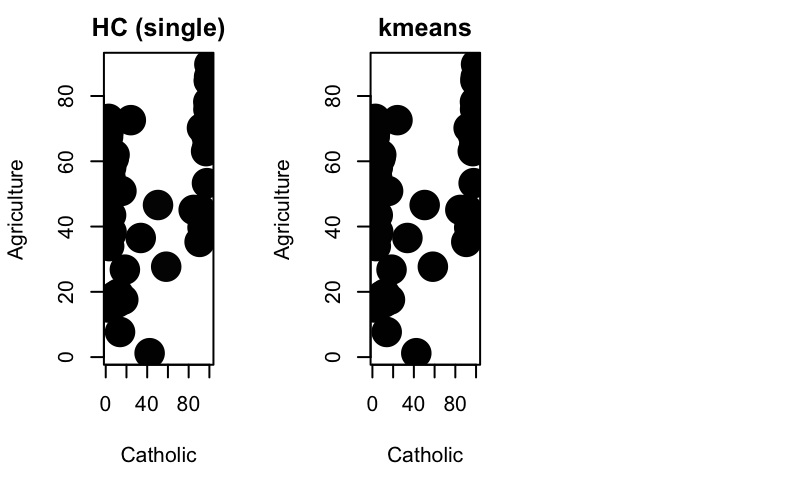

```r
plot(swiss[,c(5,2)],col=out$classification,pch=19,cex = 3,main='GMM + EM algo.')
```

Mclust offers the possibility to test for several submodels and several number of components / groups ($K$ in the course and $G$ in Mclust). A basic call to Mclust for this job is as follows:

```r
out = Mclust(swiss,G=1:5,modelNames = "VVV")
```

```
fitting ...
```

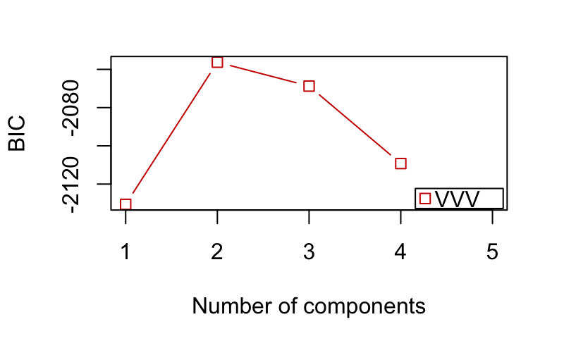

```r
plot(out, what = 'BIC')
```

> Exercise #1: do it for kmeans (EII model)

```r
out = Mclust(swiss,G=1:10,modelNames = "EII")
```

```
fitting ...
```

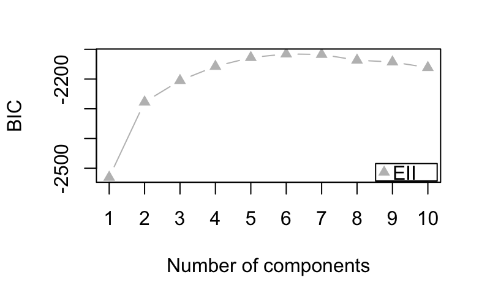

```r
plot(out, what = 'BIC')
```

Interestingly, we observe that BIC prefers $K=6$ groups for kmeans (EII model) whereas it prefered only $K=2$ groups for a more general GMM (VVV).

```r
out = Mclust(swiss,G=1:5)
```

```
fitting ...
```

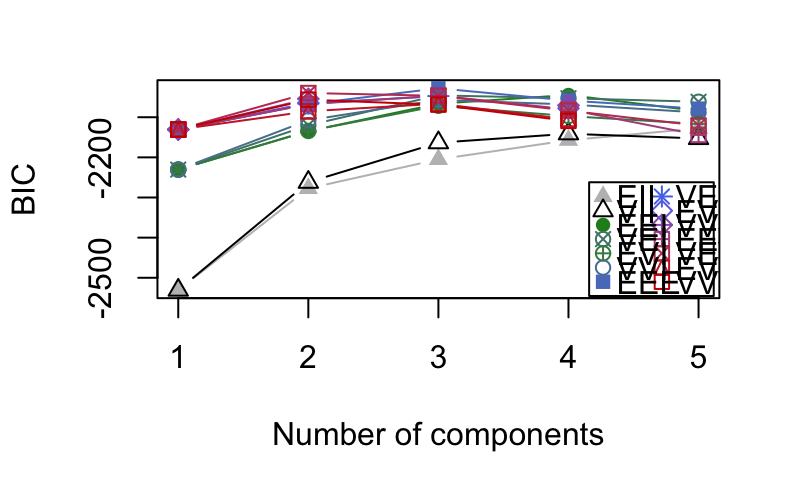

```r
plot(out, what = 'BIC')
```

We can now visualize the results.

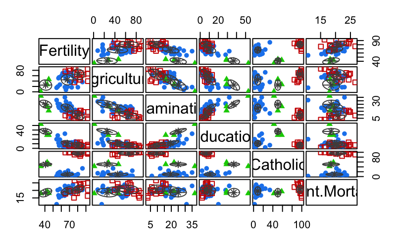

```r
plot(out,what = 'classification')
```

It is also possible to look at the uncertainty (computed from the posterior probabilities $P(Y=k|X,\hat{\theta}$, which is provided in `out$z`). The highlighted points are the ones with the higher risk of misclassification.

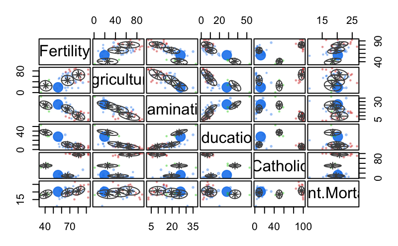

```r
plot(out,what="uncertainty")
```

By the way, it is possible to have a direct look at those posterior probabilities:

```r
round(out$z,15)
```

```
             [,1]     [,2]        [,3]
Courtelary      1 0.00e+00 0.00000e+00
Delemont        0 1.00e+00 3.00000e-14
Franches-Mnt    0 1.00e+00 0.00000e+00
Moutier         1 0.00e+00 1.28300e-12
Neuveville      1 0.00e+00 0.00000e+00
Porrentruy      0 1.00e+00 2.00000e-15
Broye           0 1.00e+00 0.00000e+00
Glane           0 1.00e+00 0.00000e+00
Gruyere         0 1.00e+00 0.00000e+00
Sarine          0 1.00e+00 0.00000e+00
Veveyse         0 1.00e+00 0.00000e+00
Aigle           1 0.00e+00 0.00000e+00
Aubonne         1 0.00e+00 0.00000e+00
Avenches        1 0.00e+00 0.00000e+00
Cossonay        1 0.00e+00 0.00000e+00
Echallens       1 0.00e+00 0.00000e+00
Grandson        1 0.00e+00 0.00000e+00
Lausanne        1 0.00e+00 3.86942e-10
La Vallee       1 0.00e+00 0.00000e+00
Lavaux          1 0.00e+00 0.00000e+00
Morges          1 0.00e+00 0.00000e+00
Moudon          1 0.00e+00 0.00000e+00
Nyone           1 0.00e+00 0.00000e+00
Orbe            1 0.00e+00 0.00000e+00
Oron            1 0.00e+00 0.00000e+00
Payerne         1 0.00e+00 0.00000e+00
Paysd'enhaut    1 0.00e+00 0.00000e+00
Rolle           1 0.00e+00 0.00000e+00
Vevey           1 0.00e+00 6.22300e-12
Yverdon         1 0.00e+00 0.00000e+00
Conthey         0 1.00e+00 0.00000e+00
Entremont       0 1.00e+00 0.00000e+00
Herens          0 1.00e+00 0.00000e+00
Martigwy        0 1.00e+00 0.00000e+00
Monthey         0 1.00e+00 0.00000e+00
St Maurice      0 1.00e+00 0.00000e+00
Sierre          0 1.00e+00 0.00000e+00
Sion            0 1.00e+00 0.00000e+00
Boudry          1 0.00e+00 0.00000e+00
La Chauxdfnd    1 0.00e+00 0.00000e+00
Le Locle        1 0.00e+00 0.00000e+00
Neuchatel       1 0.00e+00 1.60200e-12
Val de Ruz      1 0.00e+00 0.00000e+00
ValdeTravers    1 0.00e+00 0.00000e+00
V. De Geneve    0 0.00e+00 1.00000e+00
Rive Droite     0 0.00e+00 1.00000e+00
Rive Gauche     0 1.02e-13 1.00000e+00
```